# Logic and Scientific Thinking

Deduction and Induction

Bogdan G. Popescu

bgpopescu@tec.mx

Tecnologico de Monterrey

## Learning Outcomes

### Overview

1. **Classify** any argument as deductive or inductive — by the support it *claims*.
2. **Separate** validity from truth — and name the one impossible combination.
3. **Grade** arguments with the full vocabulary: valid, sound; strong, cogent.

## Warm-Up: Vitamin C

> “I caught a cold, so I took vitamin C every day. A week later the cold was gone. **Therefore**, the vitamin C cured me.”

The parts from earlier sessions, refreshed:

- **Conclusion**: *the vitamin C cured me*.
- **Premises**:
  - **P1**: took vitamin C daily;
  - **P2**: the cold ended.
- **Hidden assumption**:
  - *The cold would not have disappeared without Vitamin C*

# Part 1: Two Ways to Reason

## Two Broad Families

```
%%{init: {"flowchart": {"useMaxWidth": true, "htmlLabels": false, "nodeSpacing": 30, "rankSpacing": 110, "padding": 24}, "themeVariables": {"fontSize": "16px", "edgeLabelBackground": "#ffffff"}}}%%
flowchart LR
  P["PREMISES<br/>the reasons offered"] -->|"promise a<br/>GUARANTEE"| D["DEDUCTION<br/>premises true means<br/>conclusion MUST be true"]
  P -->|"promise a<br/>GOOD BET"| I["INDUCTION<br/>premises true means<br/>conclusion PROBABLY true"]
  style P fill:#1e293b,color:#f9fafb,stroke:#1e293b
  style D fill:#4a7c6f,color:#f9fafb,stroke:#4a7c6f
  style I fill:#b44527,color:#f9fafb,stroke:#b44527
```

**Induction** is about probability.

**Deduction** is about guarantee.

## Job 1 — Logic: Classify Arguments by Claimed Support

**Examples**:

*“95% of University students own a phone. Marco is a university student. So Marco probably owns one.”*

*“Probably”* claims a bet: **induction**.

*“Ana is taller than Luis. Luis is taller than Sofía. So Ana is taller than Sofía.”*

If the premises are true, the conclusion *can’t* be false: **deduction**.

Indicator words — *must* vs. *probably* — are clues.

## Job 2 — Methods: Direction Describes Strategies

In the social sciences, induction and deduction usually describe the direction of a research process.

```
%%{init: {"flowchart": {"useMaxWidth": true, "htmlLabels": false, "nodeSpacing": 30, "rankSpacing": 60, "padding": 14}, "themeVariables": {"fontSize": "16px", "edgeLabelBackground": "#ffffff"}}}%%
flowchart LR
  A1["DEDUCTIVE STRATEGY<br/>theory-testing"] --> B1["THEORY<br/>general"] --> C1["HYPOTHESES<br/>specific, testable"] --> D1["DATA<br/>the test"]
  A2["INDUCTIVE STRATEGY<br/>theory-building"] --> B2["DATA<br/>specific cases"] --> C2["PATTERNS<br/>regularities"] --> D2["THEORY<br/>general"]
  style A1 fill:#1e293b,color:#f9fafb,stroke:#1e293b
  style A2 fill:#1e293b,color:#f9fafb,stroke:#1e293b
  style B1 fill:#4a7c6f,color:#f9fafb,stroke:#4a7c6f
  style C1 fill:#4a7c6f,color:#f9fafb,stroke:#4a7c6f
  style D1 fill:#4a7c6f,color:#f9fafb,stroke:#4a7c6f
  style B2 fill:#b44527,color:#f9fafb,stroke:#b44527
  style C2 fill:#b44527,color:#f9fafb,stroke:#b44527
  style D2 fill:#b44527,color:#f9fafb,stroke:#b44527
```

Deduction moves from a general rule to a specific conclusion.

Induction moves from specific observations to a broader generalization.

## Explanation

The use of the induction vs deduction meaning is related.

Methods textbooks use the terms more loosely:

| Context | Deduction | Induction |
| --- | --- | --- |
| **Logic** | Premises guarantee the conclusion | Premises make the conclusion probable |
| **Research design** | Theory-testing; theory to hypothesis and data | Theory-building; data to patterns and theory |

# Flash Vote: Guarantee or Good Bet?

**1.** “All squares have four sides. This shape is a square. So it has four sides.”

**2.** “The last ten winters here were cold. So next winter will likely be cold.”

**3.** “No fish are mammals. A shark is a fish. So a shark is not a mammal.”

## Empirical Generalization

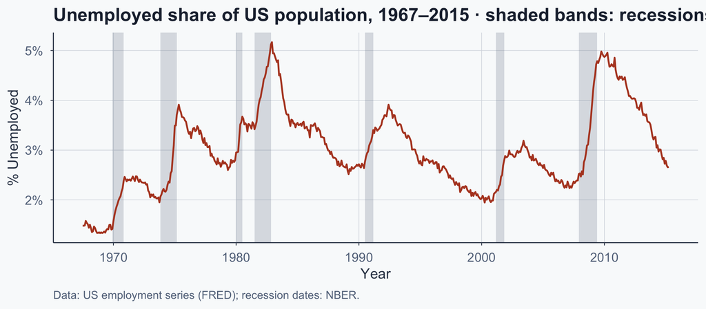

- Unemployment **rose during or soon after** each recession.
- **Therefore**, the next recession will raise unemployment
  - A bet, not a guarantee.

## The Missing “Probably”

- Honest induction should hedge: *“probably,” “likely,” “may.”*
- In real speech, that hedge is the **first thing dropped**.
- So a **bet** gets stated as a **guarantee**.
- Why? Audiences reward **confidence**, not hedging.

*“Every past technology ended up creating more jobs than it destroyed.”*

Overconfident: **“AI will create more jobs than it destroys.”**

Honest: **“AI will *probably* create new jobs too.”**

The honest move — and the rarer one — is to keep the *“probably.”*

## Warm-Up, Resolved

> “…A week later the cold was gone. **Therefore**, the vitamin C cured me.”

First question: what does the speaker **claim**?

- No *must*, no *necessarily* — a causal diagnosis from one case.
- The claim is a **good bet**, not a guarantee: **inductive**.
- So we skip validity and ask about **strength** instead.

## Hume: Induction’s Problem

> “The bread, which I formerly eat, nourished me … but does it follow, that other bread must also nourish me at another time?”

> — *An Enquiry Concerning Human Understanding* (1748), Section IV, Part II, ¶16
- Induction runs from observed cases to **unobserved** ones.
- It assumes observed patterns hold in **similar unseen cases**.
- **Deduction can’t prove that** — nature could conceivably change.
- **Experience can’t either** — that defense already uses induction *(a circle)*.
- Science **manages** this uncertainty; it never makes it **proof**.

## So What?

- Deduction **promises a guarantee** — so we can check whether it delivers.
- That check has a name: **validity**.
- It is the most misunderstood word in logic — next section fixes that.

# Part 2: Validity and Truth

## Validity: The Link

A deductive argument is valid when:

**IF** the premises are true, the conclusion **must** be true.

- Validity evaluates the **reasoning** from premises to conclusion.
- It does not tell us whether the premises are actually true.
- Truth applies to statements; **validity** applies to arguments.

**The test**: Can all the premises be true while the conclusion is false?

- **No** → valid
- **Yes** → invalid

## Valid Nonsense

| P1. | All cats are reptiles. |
| --- | --- |
| P2. | All reptiles speak French. |
| C. | All cats speak French. |

- Every line is **false**.
- Yet **if** P1 and P2 were true, C would have to be.
- The structure itself is **flawless**.
- **Valid argument, false everything.** Validity ≠ truth.

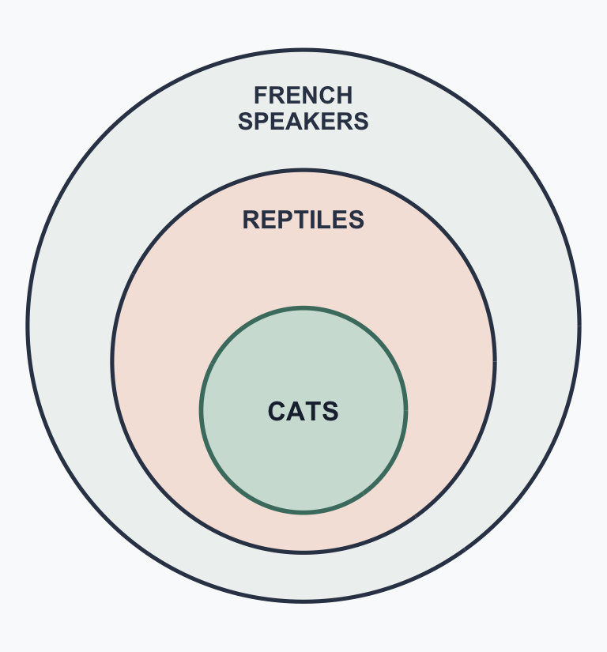

The form: *All A are B; all B are C; so all A are C* — a **categorical syllogism**.

## Same Structure, Sensible Content

| P1. | All poodles are dogs. |
| --- | --- |
| P2. | All dogs are mammals. |
| C. | All poodles are mammals. |

- Premises **true**, conclusion **true** — and it **had** to follow.
- Same structure as the French-speaking reptiles.
- **Different facts, identical logic.** Validity ignores the subject.

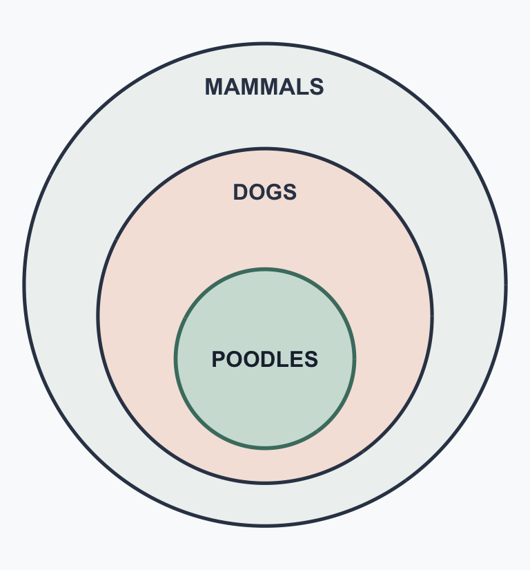

Change the content, keep the form — validity does not change.

## The Forbidden Combination

| P1. | All cats are mammals. |
| --- | --- |
| P2. | All dogs are mammals. |
| C. | All cats are dogs. |

- Both premises **true**. Conclusion plainly **false**.
- True premises **and** a false conclusion — so: **invalid**.
- Sharing a category is not being the same thing.

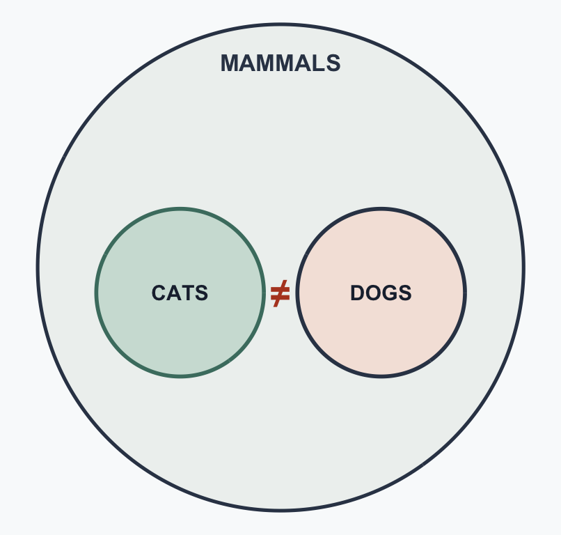

This is the one pattern a valid argument can **never** show.

## A Lucky Conclusion

| P1. | All cats are mammals. |
| --- | --- |
| P2. | All dogs are mammals. |
| C. | All whales are mammals. |

- Every line is **true** — yet the premises never mention whales.
- The conclusion is true **independently** of the premises.

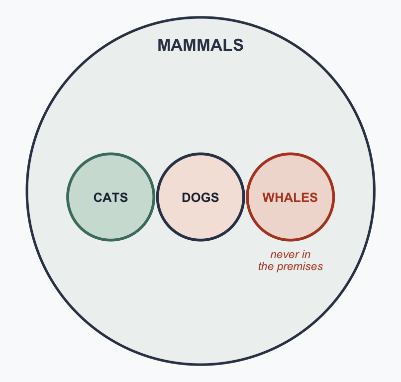

A **true conclusion** never proves the reasoning was good.

## So What?

- Validity is a **quality check on structure**
  - it ignores whether the claims are true on their own.
- But we argue to be **right about the world**.
- We need words for *valid + true* — and for good bets.
- We also need additional vocabulary: **soundness, strength, cogency**.

# Exercise 1: Sort and Judge

For each: **deductive or inductive?**

Then — if deductive: *could the premises be true yet the conclusion false?*

- (no → **valid**)

Give one sentence.

**1.** “Everyone who entered the lab signed in. Leo entered the lab. So Leo signed in.”

**2.** “Every café that opened on this street closed within a year. So this new one will too.”

**3.** “If the battery is dead, the car won’t start. The car won’t start. So the battery is dead.”

## Exercise 1 — Answers

**1.** *“Everyone who entered the lab signed in. Leo entered the lab. So Leo signed in.”*

- Guarantee → **deductive**, and it holds → **VALID**
- Everyone who entered signed, and Leo entered — he cannot have failed to sign.

**2.** *“Every café that opened on this street closed within a year. So this new one will too.”*

- Bet → **inductive** → *no validity to test*
- A bet never promised a guarantee. Its grade waits for Part 3.

**3.** *“If the battery is dead, the car won’t start. The car won’t start. So the battery is dead.”*

- Guarantee → **deductive**, but it breaks → **INVALID**
- No fuel, a bad starter — a possible cause is not the only cause.

**Validity is a question you only ask deduction.**

## Why #3 Breaks

> *“If the battery is dead, the car won’t start. The car won’t start. So the battery is dead.”*

**In standard form:**

| P1. | If the battery is dead, the car won’t start. |
| --- | --- |
| P2. | The car won’t start. |
| P3. *(hidden)* | A dead battery is the **only** thing that stops a car. |
| C. | The battery is dead. |

- P1 and P2 are **true** — but they don’t reach C on their own.
- The argument silently needs **P3**. And P3 is **false**.
- Empty tank: P1, P2 true, conclusion **false**.

**Say the hidden premise out loud and the argument dies.**

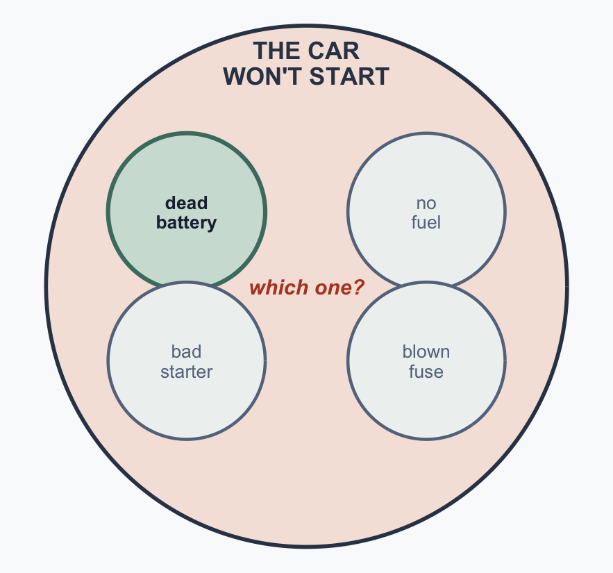

# Part 3: Grading Arguments

## Grading Arguments: Two Checks

First, identify the argument’s **claimed support**:

- **Deductive** → evaluate **validity**
- **Inductive** → evaluate **strength**

## Grading Arguments: Two Checks

### Check 1: How good is the link?

| Deductive argument | Inductive argument |
| --- | --- |
| Could the premises be true while the conclusion is false? | How probable do the premises make the conclusion? |
| **No → Valid** | **Highly probable → Strong** |
| **Yes → Invalid** | **Not very probable → Weak** |

## Grading Arguments: Two Checks

### Check 1: How good is the link?

| Deductive argument | Inductive argument |
| --- | --- |
| Could the premises be true while the conclusion is false? | How probable do the premises make the conclusion? |
| **No → Valid** |  |

**P1: If it rains, the street gets wet.**  
**P2: It rained.**  
**C: Therefore, the street is wet.**

**Why? Rain must wet the street.**  
The premises can’t be true with a false conclusion. **No → Valid**

## Grading Arguments: Two Checks

### Check 1: How good is the link?

| Deductive argument | Inductive argument |
| --- | --- |
| Could the premises be true while the conclusion is false? | How probable do the premises make the conclusion? |
| **Yes → Invalid** |  |

**P1: If it rains, the street gets wet.**  
**P2: The street is wet.**  
**C: Therefore, it rained.**

**Why? Wet doesn’t mean it rained.**  
A sprinkler could have wet it. **Yes → Invalid**

## Grading Arguments: Two Checks

### Check 1: How good is the link?

| Deductive argument | Inductive argument |
| --- | --- |
| Could the premises be true while the conclusion is false? | How probable do the premises make the conclusion? |
|  | **Highly probable → Strong** |

**P1: It has rained here every day this month.**  
**C: Therefore, it will probably rain here tomorrow.**

**Why? A month is strong evidence.**  
Many observations strongly support the conclusion. **Highly probable → Strong**

## Grading Arguments: Two Checks

### Check 1: How good is the link?

| Deductive argument | Inductive argument |
| --- | --- |
| Could the premises be true while the conclusion is false? | How probable do the premises make the conclusion? |
|  | **Not very probable → Weak** |

**P1: It rained here yesterday.**  
**C: Therefore, it will probably rain here tomorrow.**

**Why? One day proves almost nothing.**  
A single day barely supports the conclusion. **Not very probable → Weak**

## Grading Arguments: Two Checks

### Check 2: Are the premises actually true?

| Deductive arguments | Inductive arguments |
| --- | --- |
| **Valid + true premises = SOUND** | **Strong + true premises = COGENT** |

**Sound** arguments provide a deductive guarantee based on true premises.

**Cogent** arguments provide strong inductive support based on true premises.

## Grading Arguments: Two Checks

### Check 2: Are the premises actually true?

| Deductive arguments | Inductive arguments |
| --- | --- |
| **Valid + true premises = SOUND** |  |

Example:

**P1: If it rains, the street gets wet.**  
**P2: It rained.**  
**C: Therefore, the street is wet.**

The conclusion **must follow** from the premises → **Valid**  
Suppose it did in fact rain → both premises are **true**

**Therefore, the argument is SOUND.**

## Grading Arguments: Two Checks

### Check 2: Are the premises actually true?

| Deductive arguments | Inductive arguments |
| --- | --- |
|  | **Strong + true premises = COGENT** |

Example:

**P1: It has rained here every day this month.**  
**C: Therefore, it will probably rain here tomorrow.**

The premise makes the conclusion **highly probable** → **Strong**  
Suppose the month of rain checks out → the premise is **true**

**Therefore, the argument is COGENT.**

## The Four Steps

Every argument you meet, in the same order:

1. **Deductive or inductive?** *(a guarantee, or a good bet?)*
2. **Does the link hold?** *(deductive → valid? · inductive → strong?)*
3. **Are the premises true?**
4. **One-word verdict:** *sound · cogent · or neither.*

Step 1 decides which test steps 2 and 3 run.

## Take-Away: Deduction

**In plain words:**

- Good logic + true premises → **conclusion must be true.**
- Good logic, a false premise → **not proven** *(may still be true).*
- Broken logic → **doesn’t follow** *(may still be true).*

**A bad argument doesn’t make its conclusion false — it just hasn’t earned it.**

## Grade Each Argument

**Deductive or inductive? Then the link — valid / invalid, or strong / weak.**  
**Then the verdict: sound · cogent · or neither.**

**1.** “All squares have four sides. This shape is a square. So it has four sides.”

**2.** “All dogs are mammals. This animal is a mammal. So it’s a dog.”

**3.** “This mountain pass has closed from snow every winter for thirty years. So it will probably close this winter too.”

**4.** “Two of my friends got sick after eating there. So that restaurant probably has bad hygiene.”

## Grade Each Argument — Answers

**1.** *“All squares have four sides. This shape is a square. So it has four sides.”*

- Guarantee → **deductive** → **VALID**
- “Square” already forces “four sides.”
- True premises? *(assuming the shape is shown)* → **SOUND**

**2.** *“All dogs are mammals. This animal is a mammal. So it’s a dog.”*

- Guarantee → **deductive** → **INVALID**
- A cat is a mammal too — sharing a category is not being the same thing.
- Invalid already settles it → **NOT SOUND**

**3.** *“This mountain pass has closed from snow every winter for thirty years. So it will probably close this winter too.”*

- Bet → **inductive** → **STRONG**
- Thirty winters, same pass, same cause.
- True premises? *(assuming official records)* → **COGENT**

**4.** *“Two of my friends got sick after eating there. So that restaurant probably has bad hygiene.”*

- Bet → **inductive** → **WEAK**
- Two cases — out of how many diners?
- Weak already settles it → **NOT COGENT**

## Take-Away: Induction

**In plain words:**

- Strong support + true premises → **reasonable to accept** *(still revisable).*
- Strong pattern, a false premise → **not established** *(may still be true).*
- Too little evidence → **not enough to accept** *(may still be true).*

**A weak argument doesn’t make its conclusion false — it just hasn’t earned it.**

## Two Lanes, Never Crossed

**“Valid” is a deduction word. “Strong” is an induction word.** Never swap them.

```
%%{init: {"flowchart": {"useMaxWidth": true, "htmlLabels": false, "nodeSpacing": 22, "rankSpacing": 30, "padding": 20}, "themeVariables": {"fontSize": "14px", "edgeLabelBackground": "#ffffff"}}}%%
flowchart TB
  A["AN ARGUMENT<br/>what does it promise?"]
  A -->|"a GUARANTEE"| D["DEDUCTIVE"]
  A -->|"a GOOD BET"| I["INDUCTIVE"]
  D --> D1["Step 2: the link<br/>VALID or INVALID"]
  I --> I1["Step 2: the link<br/>STRONG or WEAK"]
  D1 --> D2["Step 3: premises true?<br/>then SOUND"]
  I1 --> I2["Step 3: premises true?<br/>then COGENT"]
  D2 --> D3["conclusion<br/>MUST be true"]
  I2 --> I3["conclusion<br/>PROBABLY true"]
  style A fill:#1e293b,color:#f9fafb,stroke:#1e293b
  style D fill:#4a7c6f,color:#f9fafb,stroke:#4a7c6f
  style I fill:#b44527,color:#f9fafb,stroke:#b44527
  style D1 fill:#cfe0d8,color:#1e293b,stroke:#4a7c6f
  style D2 fill:#cfe0d8,color:#1e293b,stroke:#4a7c6f
  style D3 fill:#cfe0d8,color:#1e293b,stroke:#4a7c6f
  style I1 fill:#f4e4dc,color:#1e293b,stroke:#b44527
  style I2 fill:#f4e4dc,color:#1e293b,stroke:#b44527
  style I3 fill:#f4e4dc,color:#1e293b,stroke:#b44527
```

## What You Leave With

1. **Two families**: a guarantee (deduction) or a good bet (induction).
2. **One forbidden cell**: valid + true premises + false conclusion.
3. **Four grades**: valid, sound; strong, cogent.
4. **Four steps** that grade any argument you meet.
5. **One habit**: when the support is weak, **claim less**.

## References

- Hume, D. (2007). *An enquiry concerning human understanding* (P. Millican, Ed.). Oxford University Press. (Original work published 1748; Section IV, Part II, ¶16 / SBN 33–34.)
- National Bureau of Economic Research. (2023). *US business cycle expansions and contractions*. https://www.nber.org/research/data/us-business-cycle-expansions-and-contractions